# MMR Dropout: A Predictive Approach

#### 2.0.3 *Feature Selection*

The MICS contains information about which province children live in; therefore, we were able to leveraged [World Bank](https://www.worldbank.org/en/data/interactive/2019/08/01/afghanistan-interactive-province-level-visualization) indicators for each Afghan province to provide additional geographic contextual features. This province indicators include conflict score with values closer to 100 indicating extreme instability from armed conflict, female literacy rate, health infrastructure with scores closer to 100 indicating greater delivery of medical goods to the public, population density, and poverty rate. Table 1 presents features used to predict the target outcome. We present in Figure 3 the breakdown in the target variable distributed across the provinces as well as show health institution availability and female literacy rates. We can see variation in the provinces across these indicators and our outcome variable. Overall we had 22 features in total to predict the target variable.

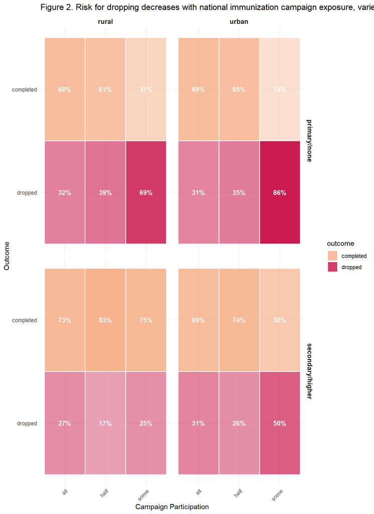

Features Used For Predicting Measles Vaccine Dropout

| variable | label |
| --- | --- |
| hh6 | Area |
| im12a | Participate in campaign, national immunization day A |
| im12b | Participate in campaign, national immunization day B |
| im12c | Participate in campaign, national immunization day C |
| im12d | Participate in campaign, national immunization day D |
| melevel | Mother’s education |
| wscore | Combined wealth score |
| hh52 | Number of children age 5-17 |
| hc3 | Number of Room in House |
| hc4 | Main material of floor |
| hc7g | Household have: A Mattress |
| hc8 | Household have electricity |
| hc14 | Household owns the dwelling |
| ws1 | Main source of drinking water |
| ws9 | Treat water to make safer for drinking |
| ws11 | Type of toilet facility |
| hw3 | Soap or detergent present at place of handwashing |
| conflict_index |  |
| female_literacy_rate |  |
| health_institutional_delivery |  |
| density_per_inhabited_area |  |
| poverty_rate |  |
| outcome |  |

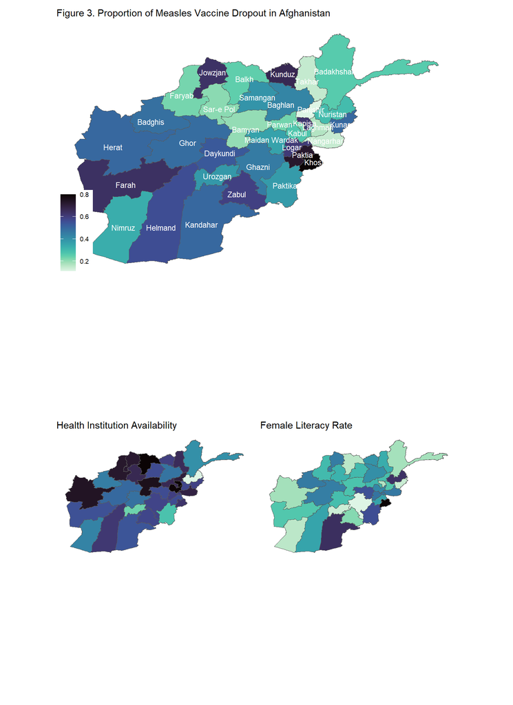

#### 2.0.5 *Feature Engineering*

Across our factor features we collapsed levels when appropriate, such as when very few cases were observed in obscure levels. For instance, very few mothers in the survey had a secondary or higher education (e.g., < 14 percent) and therefore we collapsed all levels secondary and above together. Alternatively, very few had no formal education and we collapsed this level with primary education. Access to water feature factor levels were collapsed into city, well, or other as well as access to plumbing levels were collapsed into sewer, septic, pit, outhouse, latrine, and other. One shot encoding was used for factor levels and quantitative variables such as the family wealth score and province indicators were scaled and centered.

## 3 Results

For computation we used the r-language and conducted all of our modeling using tidymodels. We tuned hyperparameters using cross validation during model training and choose models with the best AUC and F1-scores. We start with the logistic regression as a base learner to compare against ensemble methods that require parameter tuning. We show parameter tuning values in Figures 4 and 5 for all five models.

Figure 4. Hyperparameter Tuning for ML Model Training

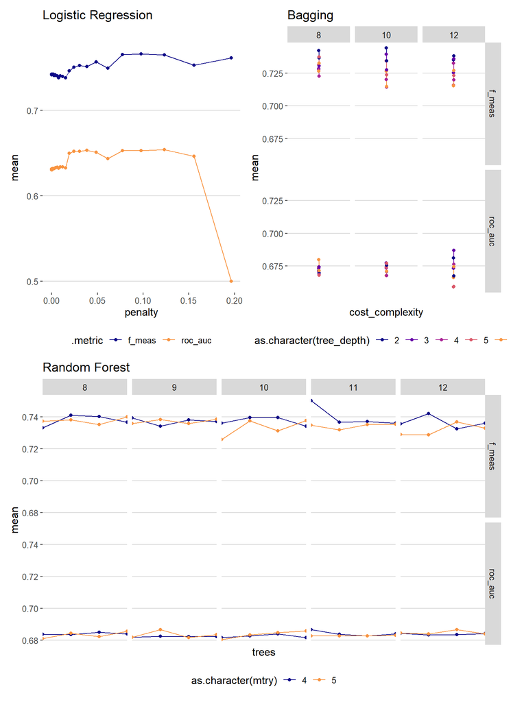

Figure 5. Continuation of Hyperparameter Tuning for ML Model Training

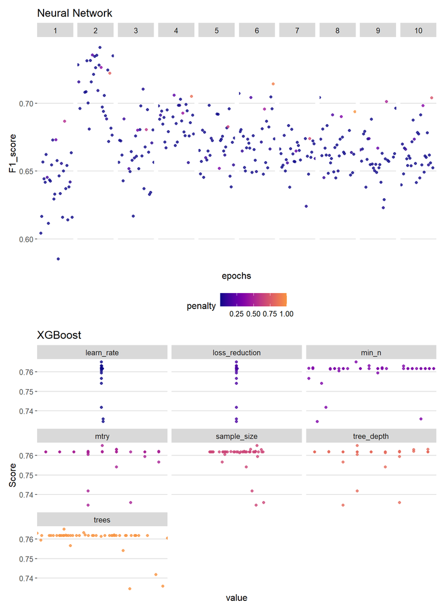

[figure not shown]

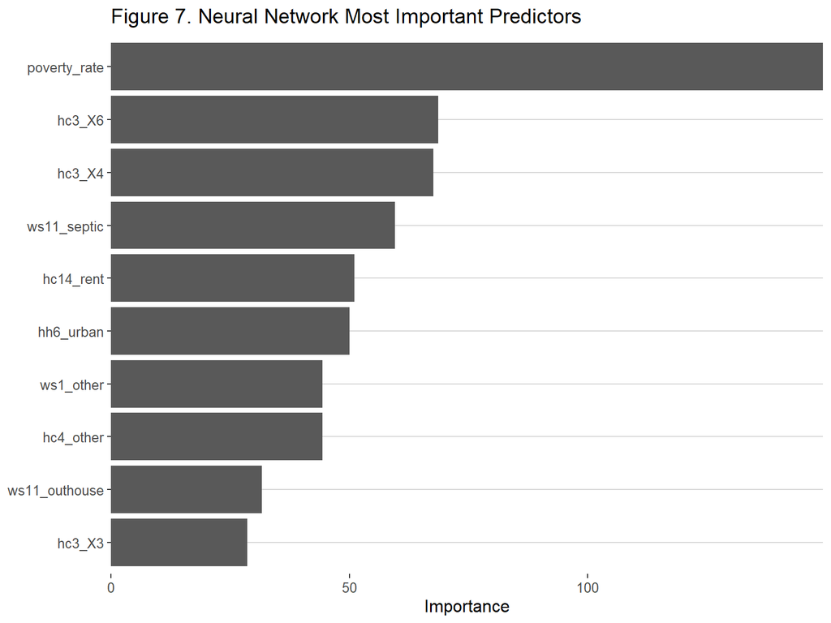

## 4 Discussion

Limitations include reliance on the small samples size of almost 1,000 respondents, necessary feature simplification such as collapsing factors, and a reliance on tool parameter specification for for model tuning. Future work could explore richer data sources or refined modeling techniques. In conclusion, this research demonstrates the utility of machine learning for identifying children at risk of measles vaccination dropout in Afghanistan. The models, despite limitations, provide actionable insights to guide targeted public health strategies aimed at improving crucial two-dose vaccination coverage.